# PD1

```python
import numpy as np
import pandas as pd
```

```python
import matplotlib.pyplot as plt
from matplotlib.ticker import MaxNLocator
import seaborn as sns
plt.style.use('ggplot')
import dalex as dx

from scipy import stats
from scipy.stats import norm


from sklearn.preprocessing import LabelEncoder
from sklearn.preprocessing import OneHotEncoder
from sklearn.compose import ColumnTransformer

import math
import warnings
warnings.filterwarnings('ignore')
np.random.seed(23)
```

```python
full_df = pd.read_csv('BankChurners.csv')
```

```python
# We don't need the unique ids'
full_df.drop('CLIENTNUM', axis=1, inplace=True)

full_df.drop(['Naive_Bayes_Classifier_Attrition_Flag_Card_Category_Contacts_Count_12_mon_Dependent_count_Education_Level_Months_Inactive_12_mon_1'],
          inplace=True, axis=1)
full_df.drop(['Naive_Bayes_Classifier_Attrition_Flag_Card_Category_Contacts_Count_12_mon_Dependent_count_Education_Level_Months_Inactive_12_mon_2'],
          inplace=True, axis=1)

display(full_df.shape)
```

```
(10127, 20)
```

```python
updated_df = pd.DataFrame()

def tobinary():

    # full_df['Attrition_Flag'] = full_df.Attrition_Flag // same thing
    updated_df['Attrition'] = full_df.Attrition_Flag.map({'Existing Customer':1, 'Attrited Customer':0})

    updated_df['Gender'] = full_df.Gender.map({'M':1, 'F':0})
```

```python
numeric_columns = ['Customer_Age','Credit_Limit','Months_on_book','Avg_Utilization_Ratio','Total_Trans_Amt','Dependent_count',
                  'Total_Relationship_Count','Months_Inactive_12_mon','Contacts_Count_12_mon','Total_Revolving_Bal',
                  'Total_Amt_Chng_Q4_Q1','Total_Ct_Chng_Q4_Q1']

def stringtoint():
    missing_income = full_df['Income_Category'].replace({'Unknown': 1 , 'Less than $40K':0, '$40K - $60K':0,
                                                      '$80K - $120K':0, '$60K - $80K':0, '$120K +':0})
    #missinng data will be replaced with mode:
    income_data    = full_df['Income_Category'].replace({'Unknown': 1 , 'Less than $40K':1, '$40K - $60K':2,
                                                      '$80K - $120K':4, '$60K - $80K':3, '$120K +':5})



    missing_education = full_df['Education_Level'].replace({'Unknown': 1, 'High School':0, 'Graduate':0, 'Uneducated':0,
                                                         'College':0,'Post-Graduate':0,'Doctorate':0})
    #missinng data will be replaced with mode:
    education_data    = full_df['Education_Level'].replace({'Unknown': 4, 'High School':2, 'Graduate':4, 'Uneducated':1,
                                                         'College':3,'Post-Graduate':5,'Doctorate':6})

    updated_df['Missing_Income']    = missing_income
    updated_df['Income_Category']   = income_data
    updated_df['Missing_Education'] = missing_education
    updated_df['Education_Level']   = education_data
```

```python
def encode():
    global updated_df
    card_dummies = pd.get_dummies(full_df['Card_Category'], prefix='Card')
    marital_dummies = pd.get_dummies(full_df['Marital_Status'], prefix='Marital')
    updated_df = pd.concat([updated_df, marital_dummies, card_dummies], axis=1)
```

```python
def concat_with_numerics():
    global updated_df
    updated_df = pd.concat([updated_df, full_df.loc[:, numeric_columns]], axis=1)
```

```python
tobinary()
stringtoint()
encode()
concat_with_numerics()
```

```python
import pickle
```

```python
m_logreg = pickle.load(open("m_logreg", 'rb'))
```

```python
from sklearn.model_selection import train_test_split

X_train, X_test, y_train, y_test = train_test_split(updated_df.drop('Attrition', axis = 1), updated_df.Attrition, test_size=0.2)
```

```python
m_logreg = m_logreg.fit(X_train, y_train)
```

```python
from sklearn.metrics import mean_squared_error

y_pred = m_logreg.predict(X_test)
mean_squared_error(y_test, y_pred, squared = False)
```

```
0.36166228049558546
```

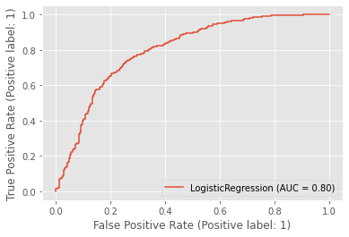

```python
from sklearn import metrics
metrics.plot_roc_curve(m_logreg, X_test, y_test)
plt.rcParams['figure.figsize'] = [10, 10]
plt.show()
```

# Dla wybranej obserwacji ze zbioru danych wylicz predykcję modelu

```python
explainer = dx.Explainer(m_logreg, X_train, y_train)
```

```
Preparation of a new explainer is initiated

  -> data              : 8101 rows 25 cols
  -> target variable   : Parameter 'y' was a pandas.Series. Converted to a numpy.ndarray.
  -> target variable   : 8101 values
  -> model_class       : sklearn.linear_model._logistic.LogisticRegression (default)
  -> label             : Not specified, model's class short name will be used. (default)
  -> predict function  : <function yhat_proba_default at 0x000002B4BB1B9790> will be used (default)
  -> predict function  : Accepts pandas.DataFrame and numpy.ndarray.
  -> predicted values  : min = 0.0527, mean = 0.841, max = 1.0
  -> model type        : classification will be used (default)
  -> residual function : difference between y and yhat (default)
  -> residuals         : min = -0.998, mean = -0.00146, max = 0.788
  -> model_info        : package sklearn

A new explainer has been created!
```

```python
explainer.predict(X_train)[4]
```

```
0.8393211454977044
```

Do zadania został użyty model regresji logicznej. Przglądając różne obserwację otrzymywałam takie wyniki jak: 0,34; 0,76; 0,98. My przyjrzymy się obserwacji o indexie 4, której predykcja wynosi ok.0.84.

# Dla wybranej obserwacji z punktu 1., wylicz dekompozycję predykcji modelu

```python
pp = explainer.predict_parts(X_train.iloc[4,:], type='shap')
pp.plot()
```

[interactive chart not shown]

Dla obserwacji o indexie 4 największą udział w predykcji mają zmienne:

- `Total_Relationship_Count` = 6, klient korzysta intensywnie z usług, więc nie ma zamiaru zamykać konta
- `Total_Revolving_Bal` = 0, klient ma bardzo ograniczone możliwości korzystania z karty, więc ujemny udział zmiennej jest może być uzasadniony
- `Contacts_Count_12_mon` = 4, klient nie zrezygnuje z usługi, ponieważ potrzebuję konta do prowadzenia tranzakcji ze swoimi "kontaktami"

# Wybierz dwie obserwacje ze zbioru danych, które mają inne najważniejsze zmienne

```python
pp_shap_C = explainer.predict_parts(X_train.iloc[21,:], type='shap')
pp_shap_C.plot()
pp_shap_D = explainer.predict_parts(X_train.iloc[1,:], type='shap')
pp_shap_D.plot()
```

[interactive chart not shown]

Pierwszy:

- `Total Revolving Bal` -0.141
- `Moths Inactive 12 mon` 0.061

Drugi:

- `Total Relationship Count`-0.12
- `Total Trans Amt` 0.069

Dla pierwszej obserwacji zmienna `Total_Revolving_Bal` ma dużo większy udział niż dla drugiej. Klienci posiadający saldo zerowe nie mogą korzystać z usługi, co może być dużą motywacją do rezygnacji z konta. Wsród zmienych mający często duży udział w predykcji, największym udział dla konkretnej obserwacji mają zmienne, które przyjmują wartości brzegowe/ odchylone od średniej.

```python
pp_shap = explainer.predict_parts(X_train.iloc[26,:], type='shap')
pp_shap.plot()
pp_shap = explainer.predict_parts(X_train.iloc[30,:], type='shap')
pp_shap.plot()
```

[interactive chart not shown]